# Hoofprint: Iowa’s Agricultural Land Use

**The Land Behind Iowa’s Livestock**

Corn, soybeans, hogs, and eggs define much of Iowa’s agricultural landscape.

In 2022, the state had 86,911 farms operating on nearly 30 million acres. Corn and soybeans occupied about 94% of harvested cropland.

Much of this land is connected to animal agriculture, whether through feed crops, grazing, or the feed ingredients produced alongside ethanol and soybean oil.

By separating land used for feed production and grazing from other uses, the project brings the land behind animal agriculture into view.

For Iowa, the project estimates a footprint of about 20.4 million acres, or 57% of the state’s land. The largest component is approximately 16.1 million acres attributed to feed production.

Corn silage and hay provide feed directly; corn grain and soybeans supply livestock alongside food, fuel, and other markets.

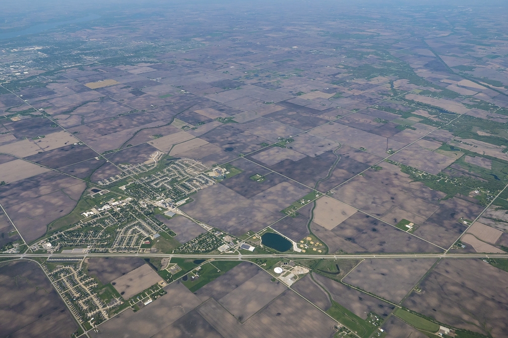

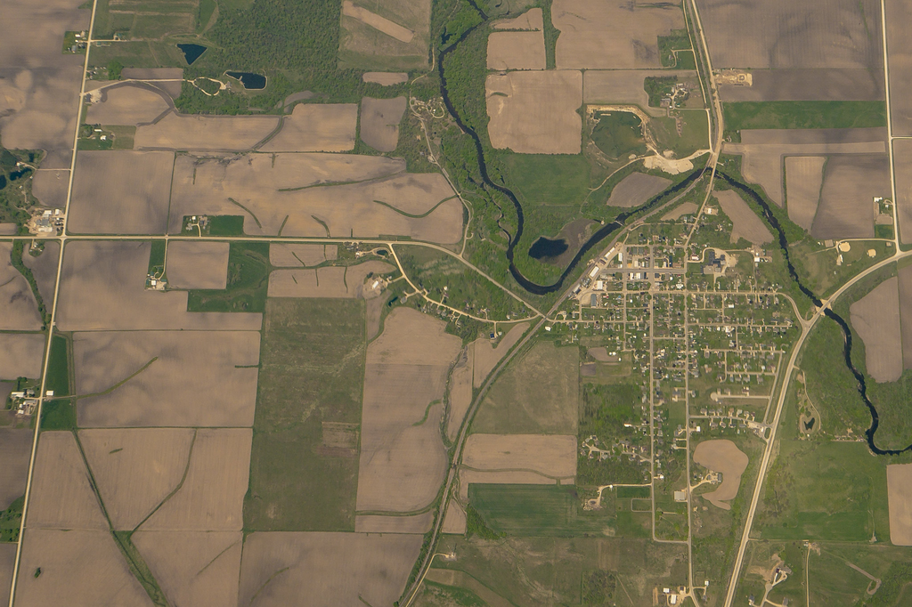

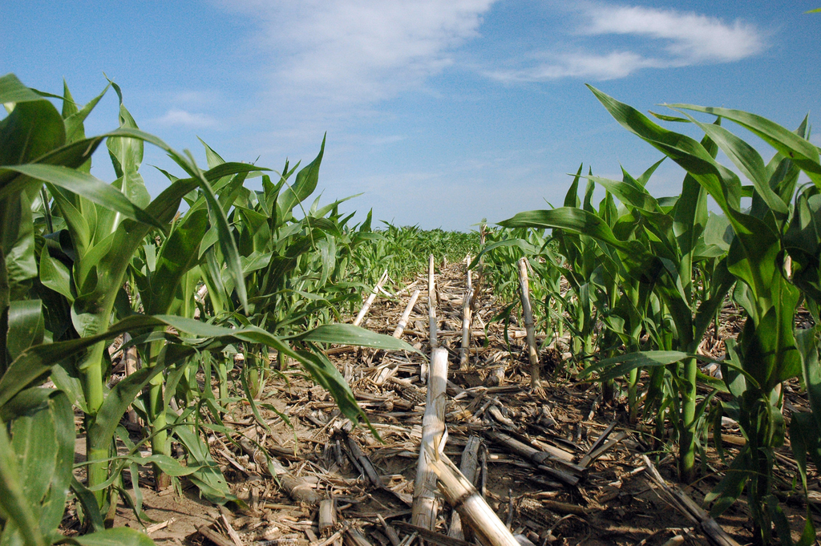

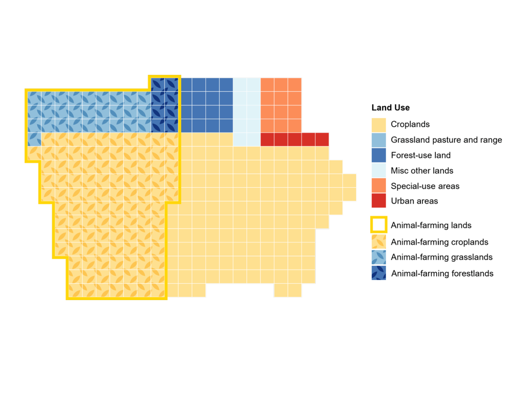

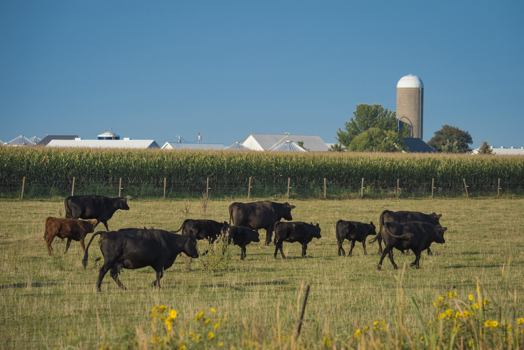

**Key Land Measures**

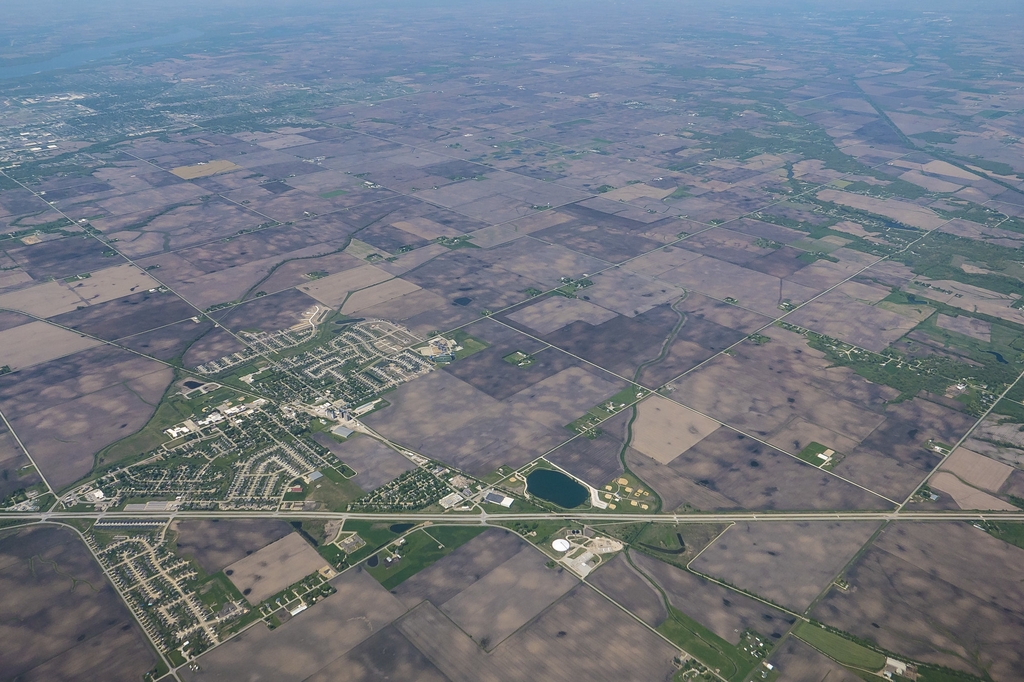

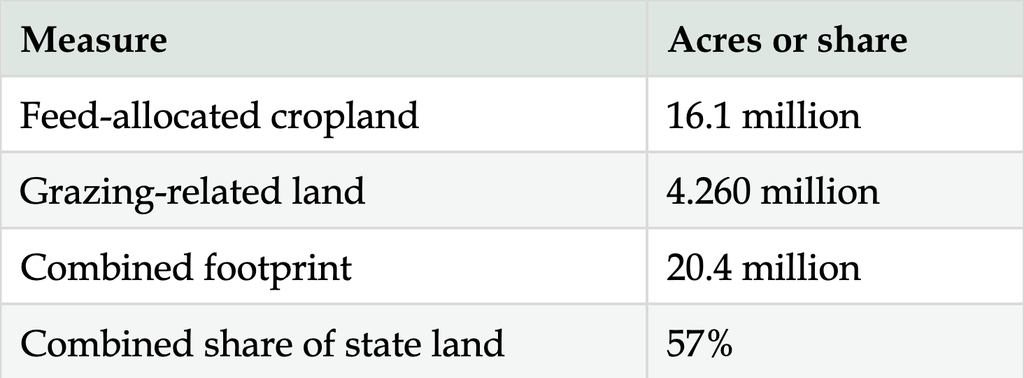

In Iowa, farm numbers rose from 90,655 in 2002 to 92,856 in 2007, fell to 86,104 in 2017, and recovered slightly to 86,911 in 2022, a net decline of 4.1% over two decades. Average farm size was 350 acres in 2002 and 345 in 2022.

At the same time, the number of farms operating at least 2,000 acres grew from 1,321 to 2,339. The statewide average thus conceals growth among the largest operations. Land in farms declined by about 645,000 acres between 2012 and 2022, or 2.1%

The following sections examine the feed systems behind these land totals and their implications for climate, conservation, and agricultural policy.

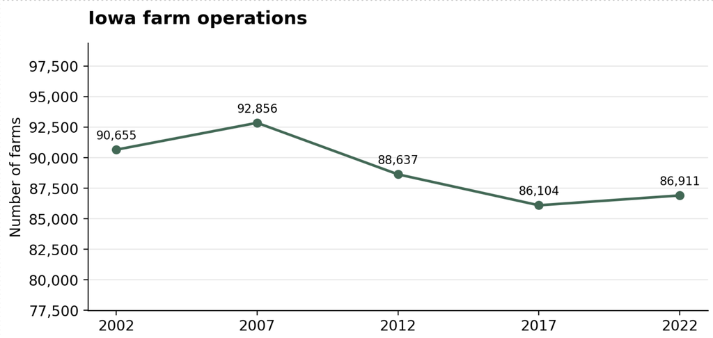

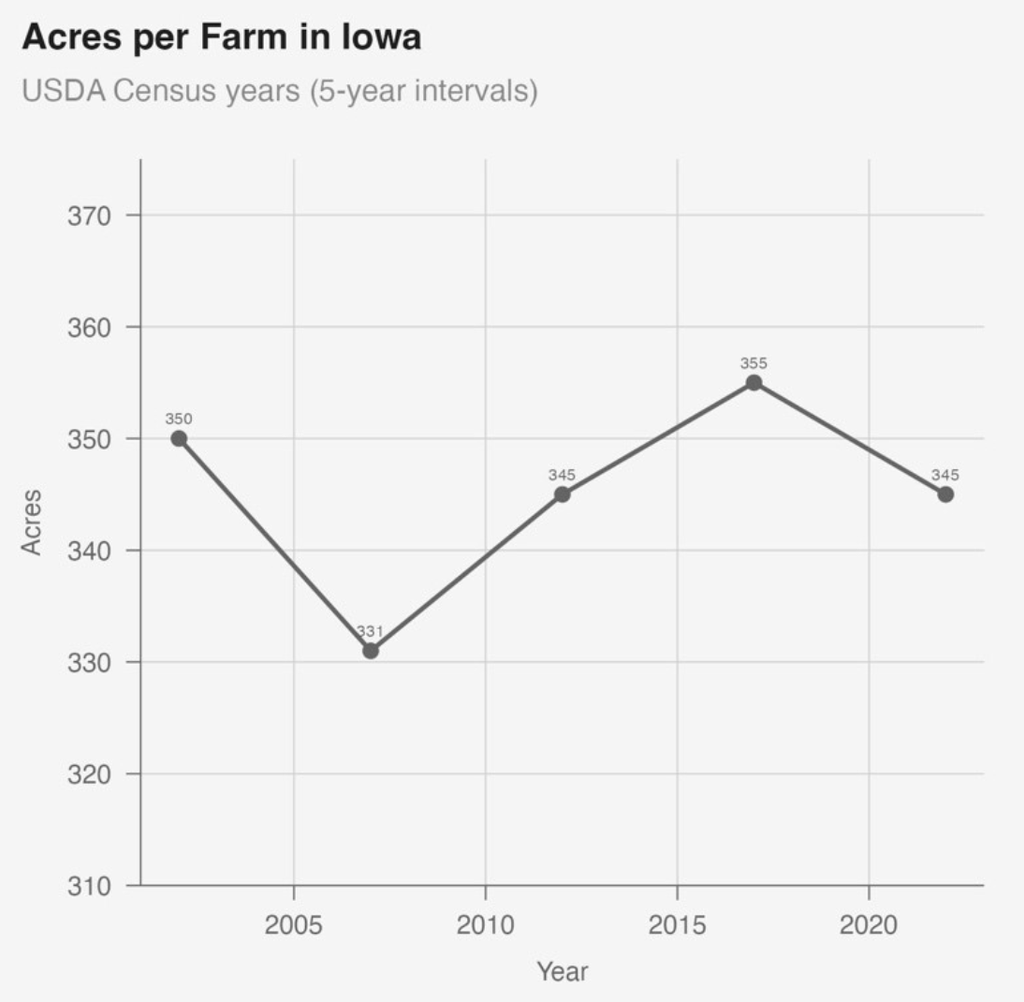

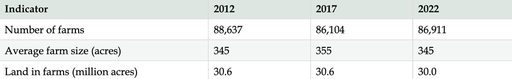

**Objective and Scope**

The analysis follows land within the state. It includes feed grown there for animals elsewhere and excludes land outside the state that supplies its livestock. It therefore describes where feed is produced, rather than the full land footprint of the animals raised within state borders.

Iowa’s hog, poultry, and cattle-feeding sectors draw on grain and protein meal, while dairy production has a more visible relationship to forage-growing areas in the northwest and northeast.

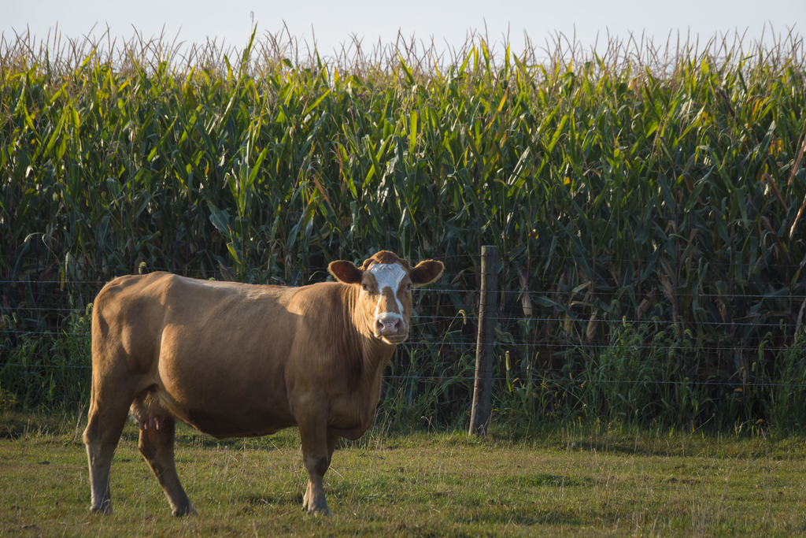

The analysis asks:

- How much land in Iowa supports crop production and grazing?
- What share of cropland can be attributed to livestock feed under explicit crop-use assumptions?
- How closely do county-level crop patterns correspond to dairy-cow and hog inventories?
- What do acreage statistics reveal about land-use choices, and what additional information is needed to evaluate their environmental consequences?

*Land Use and the Feed Estimate*

The 2017 MLU accounts record 26.728 million cropland acres, or 74.8% of the state’s 35.749 million acres. Of that cropland, 24.435 million acres were used for crops; the remainder was idle cropland or cropland pasture. The estimated 16.1 million feed acres represent about 66% of cropland used for crops and 60% of total MLU cropland. Adding grazing land gives the 20.4 million-acre footprint, approximately 57% of all state land and 66% of the crop-and-grazing base defined in the methods.

The figure on the right brings the estimated feed share of cropland together with the grazing categories. It shows how much of Iowa’s land is associated with livestock when feed fields are considered alongside pasture.

*Agriculture and the State Land Base*

Of 29.98 million acres in farms, total cropland occupied 25.88 million acres, or 86.3%, and harvested cropland occupied 23.52 million acres, or 78.5%. Permanent pasture and rangeland occupied 1.69 million acres, or 5.6%. Cropland is therefore central to understanding the land supporting livestock.

*Corn and Forage Production*

Iowa’s corn production is overwhelmingly grain-oriented. In 2024, farmers harvested 12.45 million acres for grain and 340,000 acres for silage, a split of approximately 97% and 3%. The smaller silage area has a more visible relationship to cattle-producing counties, while grain moves through feed, ethanol, food, and other markets (USDA NASS, 2024 State Agriculture Overview).

Cropland covers nearly three-quarters of Iowa.

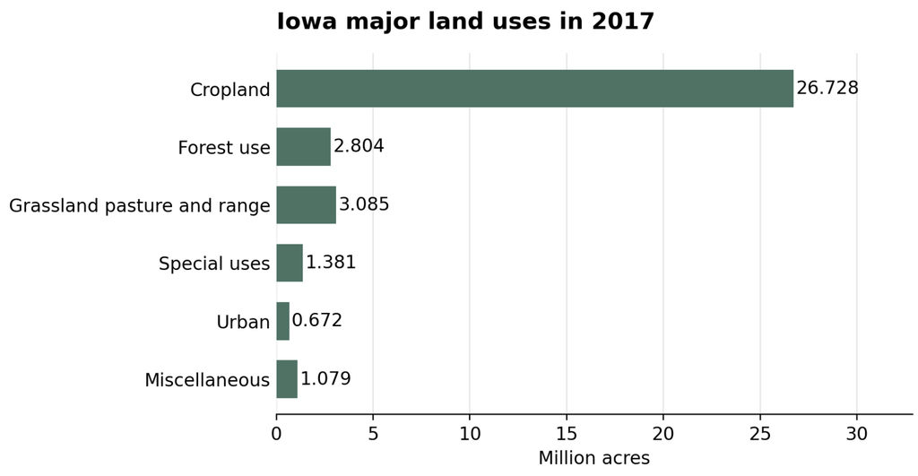

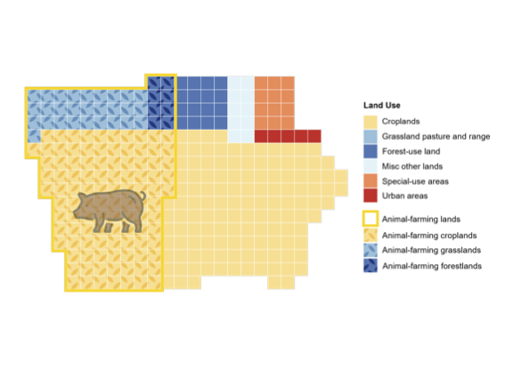

The 2022 Census provides a separate view of land operated by Iowa farms.

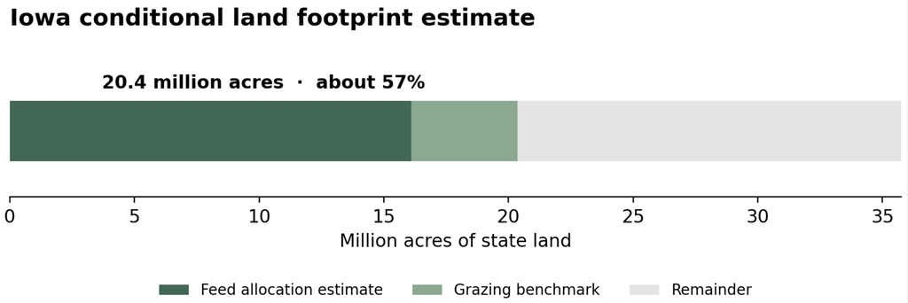

Corn and soybeans define Iowa’s agricultural landscape. In 2022, farmers harvested 12.64 million acres of corn for grain and 9.50 million acres of soybeans, together about 22.13 million acres. Corn-grain production totaled 2.51 billion bushels. Another 1.04 million acres produced hay, haylage, grass silage, and greenchop, and 250,255 acres produced corn silage or greenchop. Forage supplies feed directly, while corn grain and soybean meal connect livestock to the much larger commodity-crop system (USDA NASS, 2022, Table 1).

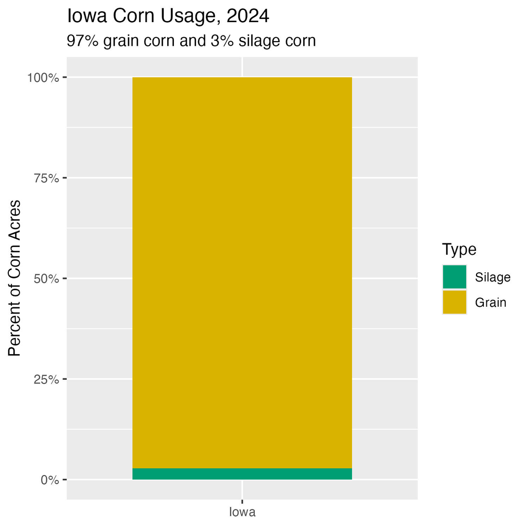

The 2022 Census counted 23.81 million hogs and pigs, 3.52 million cattle and calves, and 43.14 million laying hens in Iowa.

The cattle total included 858,556 beef cows and 238,087 milk cows, with beef cows outnumbering milk cows by about 3.6 to one. These large hog, poultry, dairy, and cattle-feeding sectors create demand for grain, protein meal, and forage. Figure 9 compares milk and beef cows in the later January 1, 2025 inventory.

Iowa’s hog inventory grew from 22.73 million in 2017 to 23.81 million in 2022 while the number of farms reporting hogs fell from 5,660 to 5,253, showing concentration within the sector. Nationally, the September 2025 NASS report found that 52% of hog inventory consisted of animals owned by operations with more than 5,000 head and raised by contractees. Iowa also had 1.21 million cattle on feed on January 1, 2025, adding substantial grain demand (USDA NASS, 2022; 2024 State Agriculture Overview; Quarterly Hogs and Pigs, September 2025).

Corn grain, soybean meal, and distillers grains connect Iowa’s crop and livestock sectors through commodity markets. Feed can cross county or state lines before reaching a livestock operation. A county with relatively little corn can therefore support many hogs, while a major corn-producing county can supply animals, ethanol plants, or export markets elsewhere.

*Livestock Systems and Feed Demand*

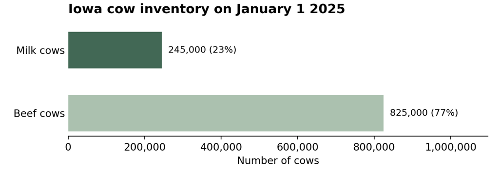

*Dairy Cows and Corn Silage*

*County Patterns in Crops and Livestock*

In the dairy clusters, corn silage and milk-cow inventories have a visible county-level relationship

Grain and soybean meal move through broader markets, and corn-grain acreage varies widely among counties with similar hog inventories

The weak hog-grain association is consistent with corn’s several end uses and the movement of feed across county lines. A fuller comparison would account for county size, source years, and missing or suppressed observations, with the coefficient, R², and sample size reported for each model.

*Pasture and Livestock Trends*

Livestock trends differed by animal class. Between 2017 and 2022, hog inventory rose 4.7%, while cattle and calves declined 11.0%, a larger percentage decline than permanent pasture. These changes offer no simple account of a shift from grazing to confinement.

They do show why pasture alone is an incomplete measure of livestock land use in a state with extensive hog, poultry, dairy, and cattle-feeding industries.

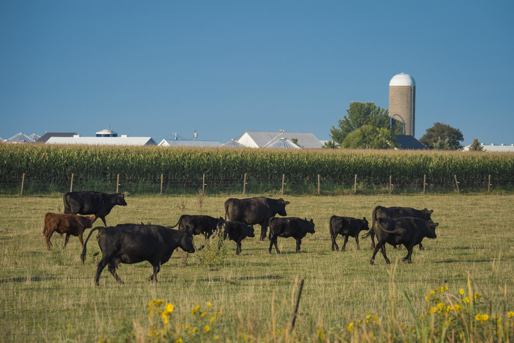

[figure not shown]

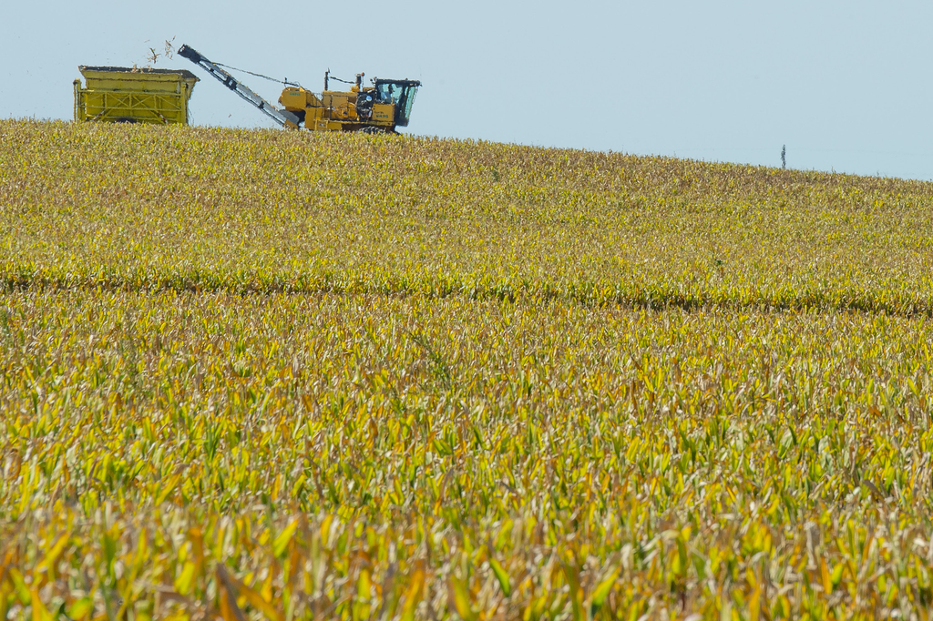

Iowa’s crop and livestock geography reflects two different feed systems.

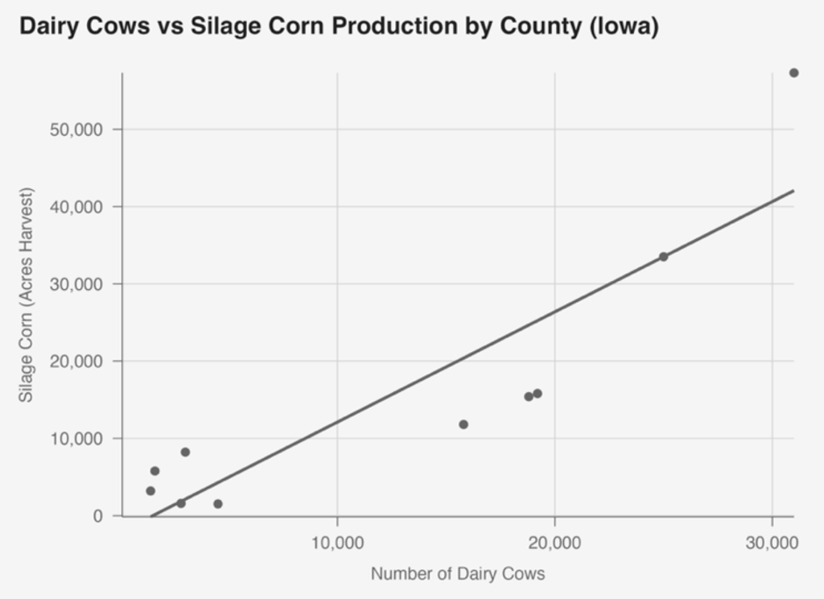

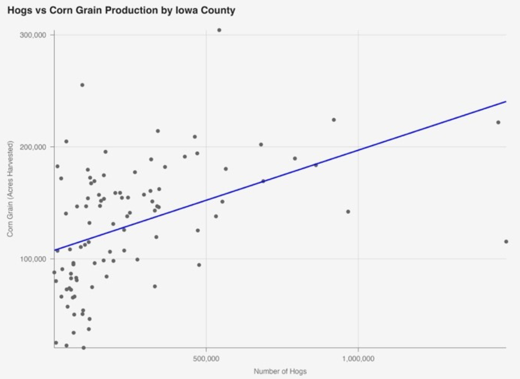

Iowa’s permanent pasture and rangeland declined from 1,780,649 acres in 2017 to 1,687,658 in 2022, a loss of 92,991 acres, or 5.2%. Adding 303,203 acres of woodland pastured and 255,065 acres of cropland pasture gives 2,245,926 acres in the three Census grazing categories in 2022, about 7.5% of land in farms. This on-farm measure differs from the broader 2017 MLU grazing estimate used for the footprint.

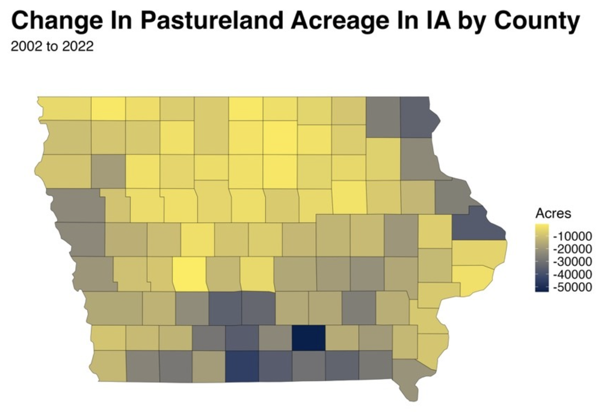

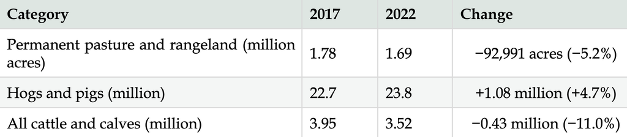

*Changes in Cropland Availability*

*Feed Purchases and Supply Chains*

*Land Use Change and Competing Uses*

*Carbon Opportunity Costs*

*Climate Risks and Agricultural Emissions*

Iowa’s 2024 greenhouse gas inventory estimates 37.45 million metric tons of carbon dioxide equivalent from agriculture, approximately 31% of gross statewide emissions. The sector includes livestock digestion, manure management, and agricultural soils, including crops grown for purposes other than feed. Hoofprint can help identify the feed-related portion of crop activity for a livestock supply-chain account, using compatible emissions factors and avoiding duplication of emissions already in the inventory (Iowa DNR, 2025).

*Air Quality and Neighboring Communities*

Iowa’s total cropland increased from 26.26 million acres in 2012 to 26.55 million in 2017, then fell to 25.88 million in 2022. The five-year decline was 664,363 acres; the net loss over the decade was 374,750 acres. Hog numbers grew between 2017 and 2022, while cattle and laying-hen inventories declined. Understanding the resulting feed demand requires information on yields, crop mix, animal productivity, and feed purchases as well as acreage.

Iowa farms reported $7.14 billion in purchased feed expenses in 2022 (USDA NASS, 2022, Table 1). This includes feed bought from outside the state but excludes feed grown and consumed on the same farm. Linking those purchases to ingredients, quantities, and origins would complement the land account. Estimating annual consumption would also require animal diets, weights, feeding periods, and turnover during the year.

Changes in total farmland can conceal different transitions. Crop fields may become pasture, conservation cover, developed land, or another agricultural use. Conservation Reserve Program enrollment can remove land from annual harvest while leaving it within a cropland or farmland category. Solar generation can displace cultivation at some sites and coexist with it at others. Following those changes would help distinguish their consequences for habitat, water, farm income, and future production.

Carbon opportunity cost is the additional carbon that land could store under a specified alternative use, compared with its current use. It captures the carbon storage forgone by continuing that use. It is evaluated through scenarios, separately from an inventory of current emissions and removals.

Iowa’s extensive feed-crop area makes alternative land uses a substantial planning question. Native prairie, wetlands where hydrology permits, and woody vegetation on suitable sites could provide carbon storage and habitat alongside water-quality benefits. The estimated 16.1 million feed acres indicate the scale of the land involved, but site conditions and farm economics determine where a transition is feasible.

A useful comparison would account for existing soil carbon, vegetation and management, the time needed to accumulate carbon, and the durability of any gain. It would also examine whether displaced production moves elsewhere. Avoided fertilizer or manure emissions should be calculated separately from additional carbon storage, with habitat, water quality, and farm income considered alongside climate benefits.

Climate change affects both feed production and the animals it supports. NOAA’s Iowa State Climate Summary reports warming of more than 1°F since the beginning of the twentieth century, concentrated in winter and fall, along with above-average spring precipitation since 1990 and more heavy precipitation events. Wetter planting seasons can delay fieldwork and increase flood exposure, while drought can damage crops during critical growth periods (Frankson et al., 2022).

NOAA projects further warming, more intense heat waves, and increases in winter and spring precipitation. Higher temperatures can intensify drought by increasing moisture loss even as average precipitation rises. These changes create linked risks for crop yields, feed costs, animal heat exposure, and farm infrastructure (Frankson et al., 2022).

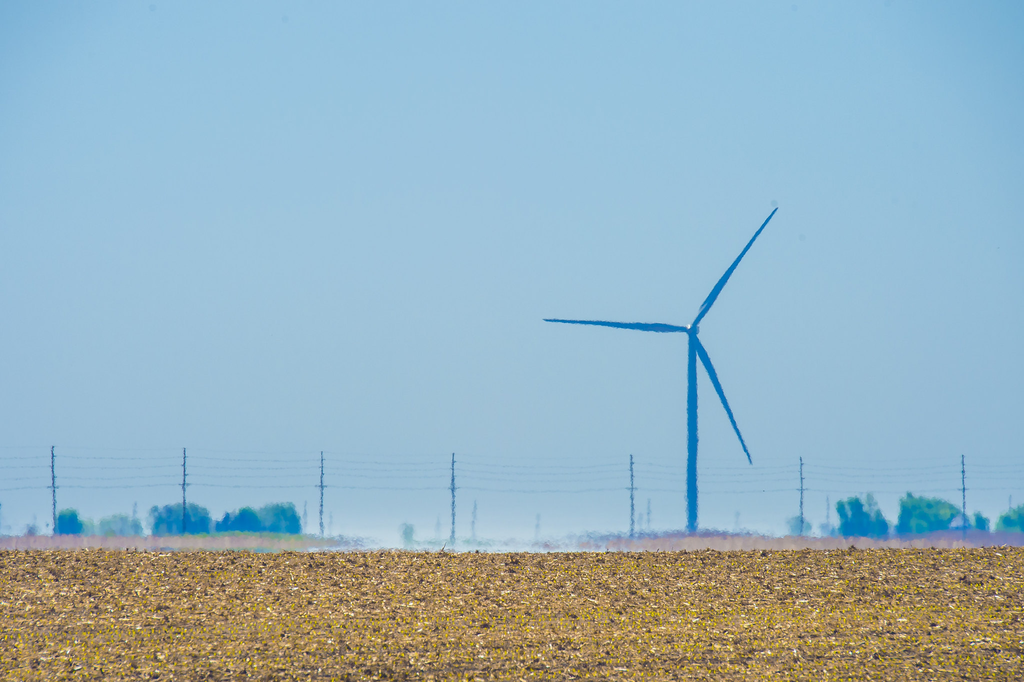

The land occupied by livestock buildings is small compared with the land supplying their feed, yet nearby communities can experience concentrated pollution. Chamanara et al. (2025) identified 2,119 hog-operation sites in Iowa covering about 10,197 hectares, or 25,200 acres. In a national matched comparison of selected census tracts, those with hog operations had approximately 11% higher fine-particle concentrations (PM2.5) than comparison tracts. The study reports an association rather than a causal or Iowa-specific exposure estimate. It supports examining the location of operations and neighboring communities alongside the broader feed footprint.

**Policy Priorities**

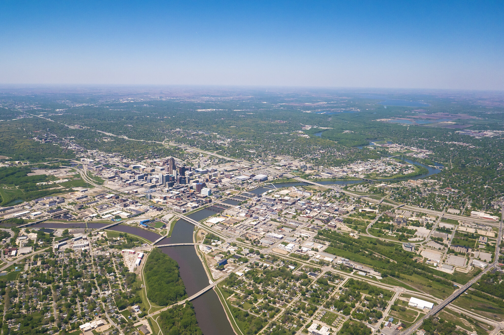

*Feed Supply Chain Transparency*

*Integrating Land Use into Climate Planning*

*Measuring Carbon Opportunity Costs*

*Diversification of Cropping Systems*

*Policies Matched to Livestock Systems*

Crop production, feed processing, and livestock operations are reported separately, making it difficult to follow feed from field to animal. Consistent reporting of major feed ingredients, quantities, and sourcing regions would help connect those records. States could begin with large livestock operations, feed mills, and processors, using existing purchasing data where possible and protecting confidential business information. Regional summaries should distinguish locally grown feed from imports and exports.

Feed production belongs in an assessment of livestock’s climate footprint. States can use feed-allocation estimates to connect crop-production emissions with the animals those crops support, while reconciling the results with existing greenhouse gas inventories to avoid double counting. Land-use scenarios can then compare continued production, changes in management, and restoration. Potential carbon gains from those alternatives should be reported separately from current emissions and removals.

A useful comparison would account for existing soil carbon, vegetation and management, the time needed to accumulate carbon, and the durability of any gain. It would also examine whether displaced production moves elsewhere. Avoided fertilizer or manure emissions should be calculated separately from additional carbon storage, with habitat, water quality, and farm income considered alongside climate benefits. In Iowa, site assessments should consider prairie, wetlands, and woody cover where ecologically suitable, using soil, drainage, erosion, habitat, land-tenure, and production information.

Support farmers who want to diversify through technical assistance, crop trials, transition funding, and markets for alternative products. Longer rotations, perennial crops, and crops grown for human food can broaden the options available to farms where soils, climate, processing capacity, and demand support them. Programs should assess effects on farm income, emissions, water quality, habitat, and total land demand.

Corn grain and soybeans occupied 22.13 million of Iowa’s 23.52 million harvested cropland acres in 2022, approximately 94%. Research in central Iowa found that integrating prairie strips into corn–soybean catchments improved biodiversity and reduced sediment and nutrient losses (Schulte et al., 2017). That provides one example of diversification within a working agricultural landscape.

Policies should reflect the livestock systems they address. Dairy regions need attention to forage sourcing and manure management; hog and poultry systems require better visibility into grain and protein-meal supply chains. Cattle feeding also connects grain and forage markets with earlier grazing stages. Changes in feeding or grazing should be assessed for their full effects on land demand, emissions, animal welfare, and neighboring communities.

**Conclusion**

Iowa’s animal agriculture is supported by fields across the state and feed markets beyond it. The estimated 20.4 million-acre footprint is dominated by cropland producing feed, with local dairy-forage relationships operating within a much larger grain economy. Making those connections clearer would help Iowa evaluate how land is used, where production and restoration can coexist, and how changes affect farms and neighboring communities.

[figure not shown]